# Topic Modeling with Movie Plot Synopses Dataset

5/2/2021

## Purpose

The purpose of this independent analysis is to analyze plot synopses of movies. For this analysis, I have used the dataset that was published in LREC 2018 @Miyazaki, Japan. The dataset includes 14K plot synopses from imdb and wikipedia. However, I have only used a subset of it to provide a deep understanding.

In this analysis, I tried to follow a similar methodology with the Kar et al. (2018) study. They also used the same dataset to analyze taggig of each movie. If you are interested in their work, you can find the article [here](https://www.aclweb.org/anthology/L18-1274.pdf).

## Guiding Question

In this analysis, I address the following question: What are the topics that indicated in movies’ written plot synopsis?

## Preparing the Dataset

The dataset includes 14K movie plot synopses and 70 tags. To clearly apply the LDA and STM packages, I created a subset (n=50) and removed the tags.

*Tidy Text*

> movie_tidy <- mysample %>%  
> unnest_tokens(output = word, input = plot_synopsis) %>%  
> anti_join(stop_words, by = “word”)

```
## # A tibble: 6,804 x 2
##    word         n
##    <chr>    <int>
##  1 tells       92
##  2 foley       84
##  3 jack        84
##  4 henry       70
##  5 parry       69
##  6 kills       65
##  7 jane        60
##  8 margaret    59
##  9 andrew      58
## 10 time        57
## # … with 6,794 more rows
```

## Term Matrix

> movie_dtm <- movie_tidy %>%  
> count(imdb_id, word) %>%  
> cast_dtm(imdb_id, word, n)

```
## <<DocumentTermMatrix (documents: 50, terms: 6804)>>
## Non-/sparse entries: 12195/328005
## Sparsity           : 96%
## Maximal term length: 22
## Weighting          : term frequency (tf)
```

## Stem words

stemmed_movie <- mysample %>%  
unnest_tokens(output = word, input = plot_synopsis) %>%  
anti_join(stop_words, by = “word”) %>%  
mutate(stem = wordStem(word)  
)

```
## # A tibble: 18,964 x 5
##    imdb_id   title                             synopsis_source word      stem
##    <chr>     <chr>                             <chr>           <chr>     <chr>
##  1 tt1546036 The Drawn Together Movie: The Mo… wikipedia       bedrock   bedrock
##  2 tt1546036 The Drawn Together Movie: The Mo… wikipedia       drunken   drunken
##  3 tt1546036 The Drawn Together Movie: The Mo… wikipedia       pregnant  pregna…
##  4 tt1546036 The Drawn Together Movie: The Mo… wikipedia       toot      toot
##  5 tt1546036 The Drawn Together Movie: The Mo… wikipedia       informed  inform
##  6 tt1546036 The Drawn Together Movie: The Mo… wikipedia       visitor   visitor
##  7 tt1546036 The Drawn Together Movie: The Mo… wikipedia       housemate housem
##  8 tt1546036 The Drawn Together Movie: The Mo… wikipedia       foxxy     foxxi
##  9 tt1546036 The Drawn Together Movie: The Mo… wikipedia       love      love
## 10 tt1546036 The Drawn Together Movie: The Mo… wikipedia       lives     live
## # … with 18,954 more rows
```

## Latent Direchlet Allocation (LDA)

My first topic model is using the LDA() function. I intentionally selects the K=10 since the dataset includes so many unique movie title.

```
## A LDA_VEM topic model with 10 topics.
```

## Structural Topic Model (STM)

As the second topic model, I used STM () function.

```
## Building corpus...
## Converting to Lower Case...
## Removing punctuation...
## Removing stopwords...
## Removing numbers...
## Stemming...
## Creating Output...
```

```
## A topic model with 7 topics, 50 documents and a 5288 word dictionary.
```

## Top Topics

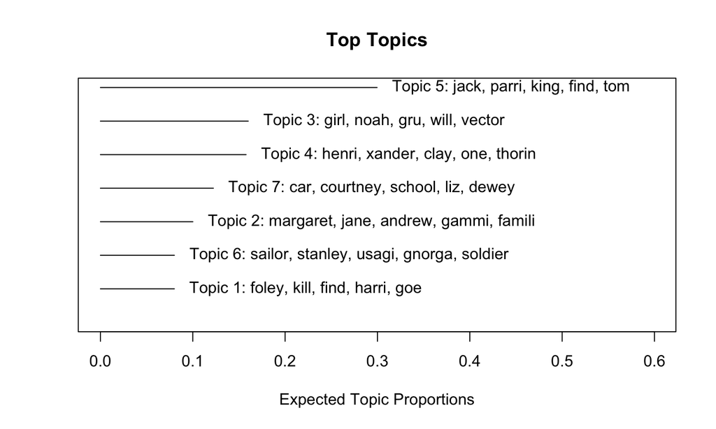

## Finding K

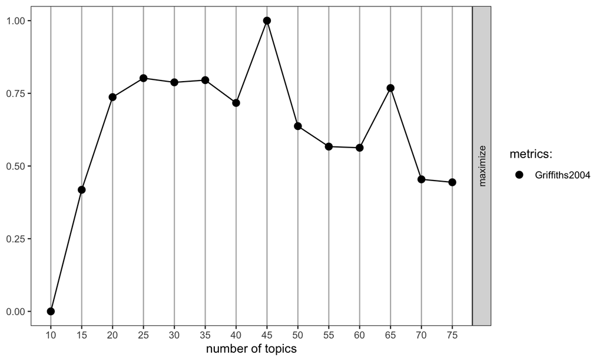